# Who Uses LinkedIn? Predicting LinkedIn Use from Demographics

**Programming II Final Project, Part 1**  
**Authors:** Muhammad Faateh Awan, Jack Hamilton, Siho Lee, Pedro Sanchez, Tina Chen

## Business context

Our marketing team is deciding which platforms to use for campaigns. The CEO asked us to study social media habits in the US public and build a model that predicts whether a person uses LinkedIn from basic demographics.

This notebook does three things:

1. **Cleans** the Pew survey data and keeps six features: income, education, parent, married, female and age.
2. **Explores** how each feature relates to LinkedIn use.
3. **Builds and tests** a logistic regression model, then uses it to score example people.

The same model powers the Streamlit app in Part 2.

## Data dictionary

| Column | Source column | Coding used in this notebook |
| --- | --- | --- |
| `sm_li` (target) | `web1h` | 1 = uses LinkedIn; 0 = every other answer |
| `income` | `income` | 1 to 9 (under 10k up to $150k+); above 9 = missing |
| `education` | `educ2` | 1 to 8 (less than high school up to postgraduate degree); above 8 = missing |
| `parent` | `par` | 1 = parent of a child under 18 at home; 0 = not; 8/9 = missing |
| `married` | `marital` | 1 = married; 0 = any other valid status; 8/9 = missing |
| `female` | `gender` | 1 = female (original code 2); 0 = male or other; 98/99 = missing |
| `age` | `age` | Age in years (97 = 97 or older); 98 = "Don't know" = missing |

```python
import pandas as pd
import numpy as np
import matplotlib.pyplot as plt
import seaborn as sns

from sklearn.model_selection import train_test_split
from sklearn.linear_model import LogisticRegression
from sklearn.metrics import confusion_matrix, classification_report

sns.set_theme(style="whitegrid", font_scale=1.05)
BLUE, GREY = "#0A66C2", "#9AA5B1"
plt.rcParams["figure.dpi"] = 110
```

## Q1. Read in the data and check its dimensions

> Read in the data, call the dataframe "s" and check the dimensions of the dataframe.

```python
s = pd.read_csv("social_media_usage.csv")
s.head()
```

|  | respid | sample | comp | int_date | lang | state | density | usr | qs1 | sex | ... | income | party | partyln | hh1 | hh3 | ql1 | ql1a | qc1 | weight | cellweight |
| --- | --- | --- | --- | --- | --- | --- | --- | --- | --- | --- | --- | --- | --- | --- | --- | --- | --- | --- | --- | --- | --- |
| 0 | 798 | 1 | 1 | 1/26/2021 | 1 | 51 | 5 | S |  | 2 | ... | 6 | 2 |  | 1 |  | 1 |  |  | 0.557187 |  |
| 1 | 1017 | 1 | 1 | 1/25/2021 | 1 | 39 | 2 | S |  | 1 | ... | 5 | 1 |  | 2 | 2 | 1 |  |  | 0.987209 |  |
| 2 | 1181 | 1 | 1 | 1/25/2021 | 1 | 32 | 2 | U |  | 2 | ... | 8 | 3 | 2 | 2 | 2 | 1 |  |  | 0.925147 |  |
| 3 | 1388 | 1 | 1 | 1/25/2021 | 1 | 4 | 3 | U |  | 1 | ... | 8 | 2 |  | 1 |  | 1 |  |  | 0.311080 |  |
| 4 | 1664 | 1 | 1 | 1/26/2021 | 1 | 12 | 2 | S |  | 2 | ... | 7 | 2 |  | 2 | 2 | 1 |  |  | 0.396548 |  |

5 rows × 89 columns

```python
print(f"Rows: {s.shape[0]:,}   Columns: {s.shape[1]}")
```

```
Rows: 1,502   Columns: 89
```

The raw survey has **1,502 respondents and 89 columns**. We only need seven of those columns for this project.

## Q2. The `clean_sm` function

> Define a function called clean_sm that takes one input, x, and uses `np.where` to check whether x is equal to 1. If it is, make the value of x = 1, otherwise make it 0. Return x. Create a toy dataframe with three rows and two columns and test your function.

```python
def clean_sm(x):
    x = np.where(x == 1, 1, 0)
    return x

toy = pd.DataFrame({"a": [1, 2, 1],
                    "b": [5, 1, 3]})

print("Original toy dataframe:")
display(toy)

print("After applying clean_sm:")
display(toy.apply(clean_sm))
```

```
Original toy dataframe:
```

|  | a | b |
| --- | --- | --- |
| 0 | 1 | 5 |
| 1 | 2 | 1 |
| 2 | 1 | 3 |

```
After applying clean_sm:
```

|  | a | b |
| --- | --- | --- |
| 0 | 1 | 0 |
| 1 | 0 | 1 |
| 2 | 1 | 0 |

The test works as expected: every 1 stays 1, and every other value (2, 3, 5) becomes 0.

## Q3. Build the clean dataframe `ss` and explore it

> Create a new dataframe called "ss" with the target `sm_li` and the features income, education, parent, married, female and age. Drop any missing values. Perform exploratory analysis to examine how the features are related to the target.

### 3.1 Cleaning

```python
ss = pd.DataFrame()

# target is LinkedIn user or not
ss["sm_li"] = clean_sm(s["web1h"])

# anything above the top category is missing for income and education
ss["income"] = np.where(s["income"] > 9, np.nan, s["income"])
ss["education"] = np.where(s["educ2"] > 8, np.nan, s["educ2"])

# yes/no features, where 8 and 9 are don't know or refused
ss["parent"] = np.where(s["par"] > 2, np.nan, clean_sm(s["par"]))
ss["married"] = np.where(s["marital"] > 6, np.nan, clean_sm(s["marital"]))

# female is coded 2 in the raw data
ss["female"] = np.where(s["gender"] > 3, np.nan, np.where(s["gender"] == 2, 1, 0))

# age 98 means don't know
ss["age"] = np.where(s["age"] >= 98, np.nan, s["age"])

# counts missing values per column, then drops them
missing = ss.isna().sum().rename("missing values")
display(missing.to_frame())

rows_before = len(ss)
ss = ss.dropna().astype(int).reset_index(drop=True)
print(f"Rows before: {rows_before:,}   Rows after dropping missing: {len(ss):,}   Dropped: {rows_before - len(ss):,}")
ss.head()
```

|  | missing values |
| --- | --- |
| sm_li | 0 |
| income | 229 |
| education | 23 |
| parent | 15 |
| married | 27 |
| female | 12 |
| age | 55 |

```
Rows before: 1,502   Rows after dropping missing: 1,250   Dropped: 252
```

|  | sm_li | income | education | parent | married | female | age |
| --- | --- | --- | --- | --- | --- | --- | --- |
| 0 | 0 | 6 | 4 | 0 | 0 | 1 | 77 |
| 1 | 0 | 5 | 3 | 0 | 0 | 0 | 59 |
| 2 | 0 | 8 | 4 | 0 | 1 | 1 | 60 |
| 3 | 0 | 8 | 8 | 0 | 0 | 0 | 73 |
| 4 | 1 | 7 | 8 | 0 | 1 | 1 | 65 |

**Two cleaning choices we made**

- **Don't know and refused answers.** The assignment only gives missing rules for income, education and age. We also dropped people who answered "Don't know" or "Refused" for parent, marital status or gender, because refusing to answer is not the same as saying no. This cost us only 10 rows (1,250 instead of 1,260).
- **Age 98.** In the codebook, 98 means "Don't know" and 97 is the highest real age. We therefore treated 98 and above as missing.

Most of the dropped rows come from income, which 229 people did not report. We are left with 1,250 people.

```python
ss.describe().T.round(2)
```

|  | count | mean | std | min | 25% | 50% | 75% | max |
| --- | --- | --- | --- | --- | --- | --- | --- | --- |
| sm_li | 1250.0 | 0.33 | 0.47 | 0.0 | 0.0 | 0.0 | 1.0 | 1.0 |
| income | 1250.0 | 5.88 | 2.47 | 1.0 | 4.0 | 6.0 | 8.0 | 9.0 |
| education | 1250.0 | 5.21 | 1.87 | 1.0 | 4.0 | 5.0 | 6.0 | 8.0 |
| parent | 1250.0 | 0.25 | 0.43 | 0.0 | 0.0 | 0.0 | 0.0 | 1.0 |
| married | 1250.0 | 0.49 | 0.50 | 0.0 | 0.0 | 0.0 | 1.0 | 1.0 |
| female | 1250.0 | 0.42 | 0.49 | 0.0 | 0.0 | 0.0 | 1.0 | 1.0 |
| age | 1250.0 | 51.23 | 18.41 | 18.0 | 36.0 | 52.0 | 65.0 | 97.0 |

### 3.2 How many people use LinkedIn?

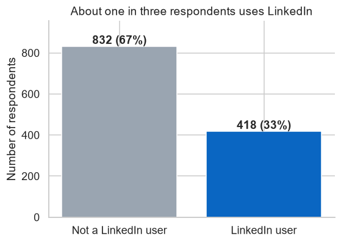

```python
counts = ss["sm_li"].value_counts().sort_index()
share = counts / counts.sum()

fig, ax = plt.subplots(figsize=(5.5, 3.8))
bars = ax.bar(["Not a LinkedIn user", "LinkedIn user"], counts.values, color=[GREY, BLUE])
for b, n, p in zip(bars, counts.values, share.values):
    ax.text(b.get_x() + b.get_width() / 2, n + 12, f"{n:,} ({p:.0%})", ha="center", fontweight="bold")
ax.set_title("About one in three respondents uses LinkedIn")
ax.set_ylabel("Number of respondents")
ax.set_ylim(0, counts.max() * 1.15)
sns.despine()
plt.show()
```

**418 of 1,250 people (33%) use LinkedIn.** The classes are not balanced, which is why the model later uses `class_weight="balanced"`.

### 3.3 LinkedIn use by each feature

This is the most important chart in the analysis. Each panel shows the share of people who use LinkedIn within each group. The dashed line is the overall rate of 33%.

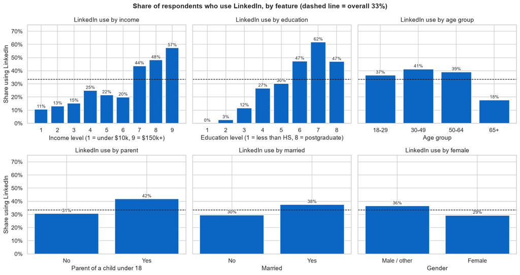

```python
overall = ss["sm_li"].mean()
ss["age_group"] = pd.cut(ss["age"], bins=[17, 29, 49, 64, 97], labels=["18-29", "30-49", "50-64", "65+"])

panels = [
    ("income", "Income level (1 = under \$10k, 9 = \$150k+)", None),
    ("education", "Education level (1 = less than HS, 8 = postgraduate)", None),
    ("age_group", "Age group", None),
    ("parent", "Parent of a child under 18", ["No", "Yes"]),
    ("married", "Married", ["No", "Yes"]),
    ("female", "Gender", ["Male / other", "Female"]),
]

fig, axes = plt.subplots(2, 3, figsize=(15, 8), sharey=True)
for ax, (col, label, ticks) in zip(axes.flatten(), panels):
    rate = ss.groupby(col, observed=True)["sm_li"].mean()
    x = ticks if ticks else rate.index.astype(str)
    bars = ax.bar(x, rate.values, color=BLUE)
    for b, v in zip(bars, rate.values):
        ax.text(b.get_x() + b.get_width() / 2, v + 0.012, f"{v:.0%}", ha="center", fontsize=9,
                bbox=dict(facecolor="white", edgecolor="none", pad=0.6), zorder=4)
    ax.axhline(overall, color="black", linestyle="--", linewidth=1)
    ax.set_title(f"LinkedIn use by {col.replace('_', ' ')}")
    ax.set_xlabel(label)
    ax.yaxis.set_major_formatter(plt.FuncFormatter(lambda v, _: f"{v:.0%}"))
    ax.set_ylim(0, 0.75)
for ax in axes[:, 0]:
    ax.set_ylabel("Share using LinkedIn")
fig.suptitle("Share of respondents who use LinkedIn, by feature (dashed line = overall 33%)", fontsize=14, fontweight="bold")
plt.tight_layout()
plt.show()
```

### 3.4 Age of users and non-users

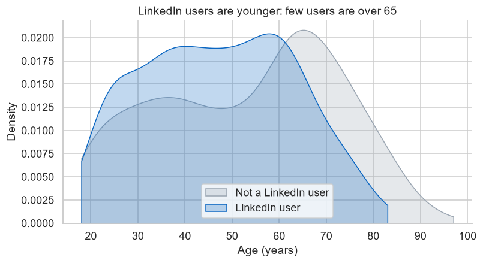

| sm_li | mean | median |
| --- | --- | --- |
| Not a user | 53.3 | 56.0 |
| LinkedIn user | 47.1 | 47.0 |

```python
fig, ax = plt.subplots(figsize=(8, 4))
sns.kdeplot(data=ss[ss["sm_li"] == 0], x="age", fill=True, color=GREY, label="Not a LinkedIn user", ax=ax, cut=0)
sns.kdeplot(data=ss[ss["sm_li"] == 1], x="age", fill=True, color=BLUE, label="LinkedIn user", ax=ax, cut=0)
ax.set_title("LinkedIn users are younger: few users are over 65")
ax.set_xlabel("Age (years)")
ax.set_ylabel("Density")
ax.legend()
sns.despine()
plt.show()

ss.groupby("sm_li")["age"].agg(["mean", "median"]).round(1).rename(index={0: "Not a user", 1: "LinkedIn user"})
```

### 3.5 Correlations

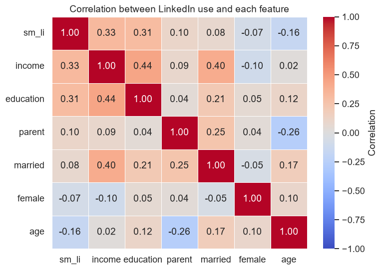

```python
features = ["income", "education", "parent", "married", "female", "age"]
corr = ss[["sm_li"] + features].corr()

fig, ax = plt.subplots(figsize=(7.5, 5.5))
sns.heatmap(corr, annot=True, fmt=".2f", cmap="coolwarm", vmin=-1, vmax=1, center=0, linewidths=0.5,
            cbar_kws={"label": "Correlation"}, ax=ax)
ax.set_title("Correlation between LinkedIn use and each feature")
plt.show()
```

### 3.6 What the exploration tells us

- **Education is the strongest signal.** Only 12% of high school graduates (level 3) use LinkedIn, compared with 47% of people with a bachelor's degree (level 6) and 47% of people with a postgraduate degree (level 8). Almost nobody without a high school diploma uses it (0% to 3%). The 62% peak at level 7 is based on only 34 people, so it should be read with care.
- **Income works the same way.** LinkedIn use is 11% in the lowest income group and 57% in the highest. There is a clear jump at level 7 ($75k and above), where use roughly doubles from about 20% to 44%.
- **Age matters mostly after 65.** Use is fairly flat for ages 18 to 64 (37% to 41%) and then falls to 18% for people 65 and older. The median user is 47 years old and the median non-user is 56.
- **The three binary features are weaker.** Parents (42% vs 31%) and married people (38% vs 30%) use LinkedIn a little more, and women a little less than men (29% vs 36%).
- **Correlations agree.** Income (0.33) and education (0.31) have the strongest link with LinkedIn use, and age is negative (-0.16). Income and education are also related to each other, so the model will share the effect between them.

**Takeaway:** LinkedIn users are more educated, higher earning and of working age. These features carry real information, so a model built on them should be useful.

## Q4. Create the target vector (y) and feature set (X)

```python
X = ss[features]
y = ss["sm_li"]

print(f"X: {X.shape[0]:,} rows and {X.shape[1]} features -> {list(X.columns)}")
print(f"y: {y.shape[0]:,} labels, {y.mean():.1%} are LinkedIn users")
```

```
X: 1,250 rows and 6 features -> ['income', 'education', 'parent', 'married', 'female', 'age']
y: 1,250 labels, 33.4% are LinkedIn users
```

## Q5. Split the data into training and test sets

> Hold out 20% of the data for testing. Explain what each new object contains and how it is used in machine learning.

```python
X_train, X_test, y_train, y_test = train_test_split(
    X, y,
    test_size=0.2,      # hold out 20% for testing
    stratify=y,         # keep the same share of LinkedIn users in both sets
    random_state=42     # make the split reproducible
)

pd.DataFrame({
    "rows": [len(X_train), len(X_test), len(y_train), len(y_test)],
    "columns": [X_train.shape[1], X_test.shape[1], 1, 1],
    "share LinkedIn users": ["", "", f"{y_train.mean():.1%}", f"{y_test.mean():.1%}"],
}, index=["X_train", "X_test", "y_train", "y_test"])
```

|  | rows | columns | share LinkedIn users |
| --- | --- | --- | --- |
| X_train | 1000 | 6 |  |
| X_test | 250 | 6 |  |
| y_train | 1000 | 1 | 33.4% |
| y_test | 250 | 1 | 33.6% |

| Object | What it contains | How it is used |
| --- | --- | --- |
| `X_train` | The six features for 80% of the people (1,000 rows) | The inputs the model learns from |
| `y_train` | The true LinkedIn answer (0 or 1) for those same 1,000 people | The model learns the link between `X_train` and these answers |
| `X_test` | The six features for the other 20% (250 rows) | Kept away from training. We feed it to the fitted model to get predictions |
| `y_test` | The true LinkedIn answer for those 250 people | We compare the predictions with these answers to measure performance |

**Why split at all?** A model can look very good on the data it has already seen. Testing on people it has never seen tells us how well it will work on new customers, which is what the marketing team cares about.

`stratify=y` keeps the share of LinkedIn users at about 33% in both sets, so the test set is a fair copy of the training set.

## Q6. Fit a logistic regression model with balanced class weights

```python
lr = LogisticRegression(class_weight="balanced", max_iter=5000)
lr.fit(X_train, y_train)
```

```
LogisticRegression(class_weight='balanced', max_iter=5000)
```

`class_weight="balanced"` gives more weight to the smaller class (LinkedIn users). Without it, the model could get about 67% accuracy by simply predicting "not a user" for everyone, which would be useless for marketing.

### What the model learned

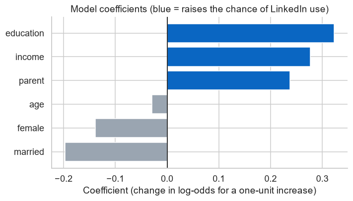

|  | coefficient | odds ratio |
| --- | --- | --- |
| married | -0.198 | 0.821 |
| female | -0.138 | 0.871 |
| age | -0.029 | 0.971 |
| parent | 0.237 | 1.268 |
| income | 0.277 | 1.319 |
| education | 0.323 | 1.381 |

```python
coefs = pd.DataFrame({
    "coefficient": lr.coef_[0],
    "odds ratio": np.exp(lr.coef_[0]),
}, index=features).sort_values("coefficient")

fig, ax = plt.subplots(figsize=(7, 3.6))
ax.barh(coefs.index, coefs["coefficient"], color=[BLUE if v > 0 else GREY for v in coefs["coefficient"]])
ax.axvline(0, color="black", linewidth=1)
ax.set_title("Model coefficients (blue = raises the chance of LinkedIn use)")
ax.set_xlabel("Coefficient (change in log-odds for a one-unit increase)")
sns.despine()
plt.show()

coefs.round(3)
```

- **Education and income are positive.** Each step up in education multiplies the odds of using LinkedIn by about 1.38, and each step up in income by about 1.32, holding the other features fixed.
- **Age is negative.** Each extra year multiplies the odds by about 0.97. This looks small, but it is per year: over 40 years it is a large drop (see Q10).
- **Female is slightly negative and parent slightly positive**, in line with the exploration.
- **Married turns negative.** In the raw data, married people use LinkedIn more. Once the model accounts for income (married households tend to report higher household income), being married no longer adds anything and the sign flips. This is a small effect.

Note that age is measured in years while the other features are on short scales, so coefficient sizes cannot be compared directly across features.

## Q7. Evaluate the model on the test data

> What is the model accuracy? Use the model to make predictions and then generate a confusion matrix. Interpret the confusion matrix and explain what each number means.

```python
y_pred = lr.predict(X_test)

accuracy = lr.score(X_test, y_test)
print(f"Test accuracy: {accuracy:.3f} ({accuracy:.1%})")

cm = confusion_matrix(y_test, y_pred)
print("\nConfusion matrix:")
print(cm)
```

```
Test accuracy: 0.704 (70.4%)

Confusion matrix:
[[121  45]
 [ 29  55]]
```

The model has a **test accuracy of 70.4%**: it classifies 176 of the 250 test people correctly.

What each number in the confusion matrix means:

| Number | Name | Meaning |
| --- | --- | --- |
| **121** | True negatives | Not LinkedIn users, and the model correctly said "not a user" |
| **45** | False positives | Not LinkedIn users, but the model wrongly said "user" |
| **29** | False negatives | LinkedIn users, but the model wrongly said "not a user" |
| **55** | True positives | LinkedIn users, and the model correctly said "user" |

The model makes more false positives (45) than false negatives (29). This is a direct result of the balanced class weights: the model is tuned to find users, so it would rather flag too many people than miss real users. For a marketing team that wants reach, this is a reasonable trade.

Accuracy on its own can mislead here, because predicting "not a user" for everyone would already score 66.4%. Precision, recall and F1 in Q9 give a fuller picture.

## Q8. Confusion matrix as a labelled dataframe

```python
cm_df = pd.DataFrame(
    cm,
    index=["Actual: Not a user (0)", "Actual: LinkedIn user (1)"],
    columns=["Predicted: Not a user (0)", "Predicted: LinkedIn user (1)"],
)
cm_df
```

|  | Predicted: Not a user (0) | Predicted: LinkedIn user (1) |
| --- | --- | --- |
| Actual: Not a user (0) | 121 | 45 |
| Actual: LinkedIn user (1) | 29 | 55 |

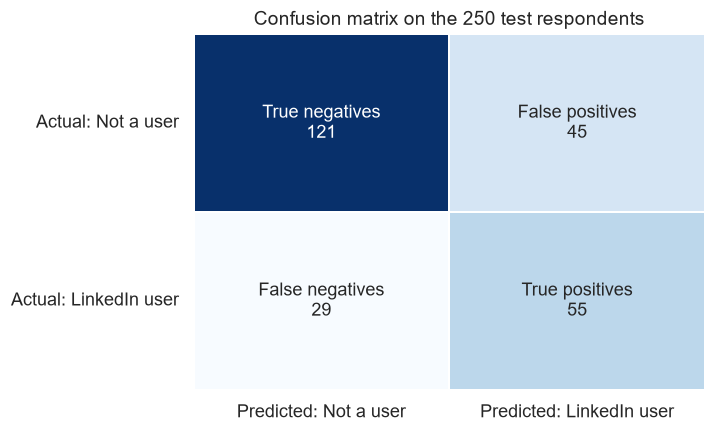

```python
labels = np.array([["True negatives", "False positives"], ["False negatives", "True positives"]])
annot = np.array([[f"{labels[i, j]}\n{cm[i, j]}" for j in range(2)] for i in range(2)])

fig, ax = plt.subplots(figsize=(6, 4.2))
sns.heatmap(cm_df, annot=annot, fmt="", cmap="Blues", cbar=False, linewidths=1, annot_kws={"fontsize": 12}, ax=ax)
ax.set_title("Confusion matrix on the 250 test respondents")
ax.set_xticklabels(["Predicted: Not a user", "Predicted: LinkedIn user"])
ax.set_yticklabels(["Actual: Not a user", "Actual: LinkedIn user"], rotation=0)
plt.show()
```

## Q9. Precision, recall and F1 score

> Use the results in the confusion matrix to calculate each of these metrics by hand. Discuss each metric and give an example of when it might be the preferred metric. Then create a classification_report and check that the metrics match.

### 9.1 Calculating by hand

```python
tn, fp, fn, tp = cm.ravel()

precision = tp / (tp + fp)
recall = tp / (tp + fn)
f1 = 2 * (precision * recall) / (precision + recall)

print(f"TN = {tn}, FP = {fp}, FN = {fn}, TP = {tp}\n")
print(f"Precision = TP / (TP + FP) = {tp} / ({tp} + {fp}) = {precision:.3f}")
print(f"Recall    = TP / (TP + FN) = {tp} / ({tp} + {fn}) = {recall:.3f}")
print(f"F1 score  = 2 x (P x R) / (P + R) = 2 x ({precision:.3f} x {recall:.3f}) / ({precision:.3f} + {recall:.3f}) = {f1:.3f}")
```

```
TN = 121, FP = 45, FN = 29, TP = 55

Precision = TP / (TP + FP) = 55 / (55 + 45) = 0.550
Recall    = TP / (TP + FN) = 55 / (55 + 29) = 0.655
F1 score  = 2 x (P x R) / (P + R) = 2 x (0.550 x 0.655) / (0.550 + 0.655) = 0.598
```

### 9.2 What each metric means

**Precision = 0.550.** Of the 100 people the model called LinkedIn users, 55 really are.  
*When to prefer it:* when a false positive is expensive. Example: a paid LinkedIn ad campaign with a small budget, where every person we wrongly target is wasted money. A spam filter is another case, because sending a real email to the spam folder is costly.

**Recall = 0.655.** Of the 84 real LinkedIn users in the test set, the model found 55.  
*When to prefer it:* when missing a positive is expensive. Example: disease screening, where missing a sick patient is much worse than sending a healthy one for a second test. In marketing, recall matters for a cheap, broad awareness campaign where we want to reach as many real users as possible.

**F1 score = 0.598.** The harmonic mean of precision and recall. It is only high when both are high.  
*When to prefer it:* when the classes are imbalanced and both kinds of error matter, so one number is needed to compare models. Example: fraud detection, where blocking honest customers and missing real fraud are both costly. It is also the fairest single number for this project, because only one third of people are users.

### 9.3 Check against sklearn

```python
print(classification_report(y_test, y_pred, target_names=["Not a user (0)", "LinkedIn user (1)"]))
```

```
                   precision    recall  f1-score   support

   Not a user (0)       0.81      0.73      0.77       166
LinkedIn user (1)       0.55      0.65      0.60        84

         accuracy                           0.70       250
        macro avg       0.68      0.69      0.68       250
     weighted avg       0.72      0.70      0.71       250
```

```python
report = classification_report(y_test, y_pred, output_dict=True)["1"]
check = pd.DataFrame({
    "by hand": [precision, recall, f1],
    "sklearn": [report["precision"], report["recall"], report["f1-score"]],
}, index=["precision", "recall", "f1 score"])
check["match"] = np.isclose(check["by hand"], check["sklearn"])
check.round(3)
```

|  | by hand | sklearn | match |
| --- | --- | --- | --- |
| precision | 0.550 | 0.550 | True |
| recall | 0.655 | 0.655 | True |
| f1 score | 0.598 | 0.598 | True |

The hand calculations match the `classification_report` row for LinkedIn users (class 1): precision 0.55, recall 0.65 (0.655 before sklearn rounds it) and F1 0.60.

## Q10. Use the model to make predictions

> What is the probability that a high income (income = 8), highly educated (education = 7), non-parent, married female who is 42 years old uses LinkedIn? How does the probability change if another person is 82 years old, but otherwise the same?

```python
people = pd.DataFrame({
    "income": [8, 8],
    "education": [7, 7],
    "parent": [0, 0],
    "married": [1, 1],
    "female": [1, 1],
    "age": [42, 82],
}, index=["Person 1 (age 42)", "Person 2 (age 82)"])[features]

results = people.copy()
results["probability of LinkedIn use"] = lr.predict_proba(people)[:, 1].round(3)
results["predicted class"] = np.where(lr.predict(people) == 1, "LinkedIn user", "Not a user")
results
```

|  | income | education | parent | married | female | age | probability of LinkedIn use | predicted class |
| --- | --- | --- | --- | --- | --- | --- | --- | --- |
| Person 1 (age 42) | 8 | 7 | 0 | 1 | 1 | 42 | 0.719 | LinkedIn user |
| Person 2 (age 82) | 8 | 7 | 0 | 1 | 1 | 82 | 0.443 | Not a user |

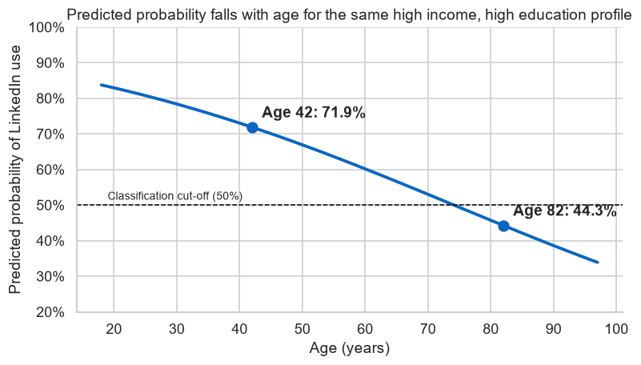

```
Change from age 42 to age 82: -27.6 percentage points
```

```python
ages = np.arange(18, 98)
grid = pd.DataFrame({"income": 8, "education": 7, "parent": 0, "married": 1, "female": 1, "age": ages})[features]
probs = lr.predict_proba(grid)[:, 1]
p42, p82 = lr.predict_proba(people)[:, 1]

fig, ax = plt.subplots(figsize=(8, 4.2))
ax.plot(ages, probs, color=BLUE, linewidth=2.5)
ax.axhline(0.5, color="black", linestyle="--", linewidth=1)
ax.text(19, 0.515, "Classification cut-off (50%)", fontsize=9)
for a, p in [(42, p42), (82, p82)]:
    ax.scatter(a, p, color=BLUE, s=70, zorder=3)
    ax.annotate(f"Age {a}: {p:.1%}", (a, p), textcoords="offset points", xytext=(8, 8), fontweight="bold")
ax.set_title("Predicted probability falls with age for the same high income, high education profile")
ax.set_xlabel("Age (years)")
ax.set_ylabel("Predicted probability of LinkedIn use")
ax.yaxis.set_major_formatter(plt.FuncFormatter(lambda v, _: f"{v:.0%}"))
ax.set_ylim(0.2, 1)
sns.despine()
plt.show()

print(f"Change from age 42 to age 82: {(p82 - p42) * 100:.1f} percentage points")
```

- **The 42-year-old** has a predicted probability of **71.9%**, so the model classifies her as a LinkedIn user.
- **The 82-year-old**, who is the same in every other way, has a predicted probability of **44.3%**, so the model classifies her as not a user.
- Forty extra years lower the probability by **27.6 percentage points** and move the person to the other side of the 50% cut-off, at around age 74 for this profile.

**Two cautions when reading these numbers**

1. **The probabilities are relative scores.** Because of `class_weight="balanced"`, the model's probabilities run higher than the true rates (the true overall rate is 33%). They are good for ranking people and for the yes/no classification, but 71.9% should not be read as "72 in 100 people like this use LinkedIn".
2. **This is a pattern, not a cause.** The model shows that older people in this survey use LinkedIn less. It does not prove that ageing makes someone leave LinkedIn. Many older respondents are retired, and work status is not in the model.

## Conclusion and recommendations for the marketing team

**What we found**

- About **one in three** US adults in the survey uses LinkedIn.
- LinkedIn users are **more educated, higher earning and of working age**. Use is 47% among bachelor's degree holders compared with 12% among high school graduates, and it more than doubles once household income passes $75k.
- Use drops sharply after 65 (18%).
- Gender, marital status and being a parent matter much less.

**How good is the model?**

- Accuracy 70%, recall 65%, precision 55%, F1 0.60 on people it had never seen.
- It finds about two out of three real LinkedIn users. About half of the people it flags are real users, compared with one in three if we picked people at random.

**Recommendations**

1. **Use LinkedIn for campaigns aimed at college-educated professionals with household income above $75k**, aged roughly 25 to 64. This is where LinkedIn reach is strongest.
2. **Do not rely on LinkedIn to reach people over 65 or people without a college education.** Other platforms should be considered for those segments.
3. **Use the model as a first screen, not a final answer.** It is good for ranking segments by likely LinkedIn use. For expensive, tightly targeted campaigns, raise the probability cut-off above 50% to improve precision.

**Limits and next steps**

- The model uses only six demographic features. Employment status, industry and job type would likely improve it a lot.
- The data is a single Pew survey, so results should be refreshed as platform use changes.
- Part 2 turns this model into an interactive Streamlit app, so the marketing team can enter a customer profile and see the prediction in real time.